# Polynomial Regression and Splines

Phoebe Tan

2023-08-26

**Polynomial Regression**

Like a linear regression model, except that the regression are powers of X.

**Spline Interpolation**

A form of interpolation where the interpolant is a special type of piece wise polynomial called a spline.

## Preprocessing Data

```r
#Data Link: https://www.kaggle.com/datasets/rajyellow46/wine-quality
data= read.csv("winequalityN.csv")
str(data)
```

```
## 'data.frame':    6497 obs. of  13 variables:
##  $ type                : chr  "white" "white" "white" "white" ...
##  $ fixed.acidity       : num  7 6.3 8.1 7.2 7.2 8.1 6.2 7 6.3 8.1 ...
##  $ volatile.acidity    : num  0.27 0.3 0.28 0.23 0.23 0.28 0.32 0.27 0.3 0.22 ...
##  $ citric.acid         : num  0.36 0.34 0.4 0.32 0.32 0.4 0.16 0.36 0.34 0.43 ...
##  $ residual.sugar      : num  20.7 1.6 6.9 8.5 8.5 6.9 7 20.7 1.6 1.5 ...
##  $ chlorides           : num  0.045 0.049 0.05 0.058 0.058 0.05 0.045 0.045 0.049 0.044 ...
##  $ free.sulfur.dioxide : num  45 14 30 47 47 30 30 45 14 28 ...
##  $ total.sulfur.dioxide: num  170 132 97 186 186 97 136 170 132 129 ...
##  $ density             : num  1.001 0.994 0.995 0.996 0.996 ...
##  $ pH                  : num  3 3.3 3.26 3.19 3.19 3.26 3.18 3 3.3 3.22 ...
##  $ sulphates           : num  0.45 0.49 0.44 0.4 0.4 0.44 0.47 0.45 0.49 0.45 ...
##  $ alcohol             : num  8.8 9.5 10.1 9.9 9.9 10.1 9.6 8.8 9.5 11 ...
##  $ quality             : int  6 6 6 6 6 6 6 6 6 6 ...
```

```r
head(data)
```

```
##    type fixed.acidity volatile.acidity citric.acid residual.sugar chlorides
## 1 white           7.0             0.27        0.36           20.7     0.045
## 2 white           6.3             0.30        0.34            1.6     0.049
## 3 white           8.1             0.28        0.40            6.9     0.050
## 4 white           7.2             0.23        0.32            8.5     0.058
## 5 white           7.2             0.23        0.32            8.5     0.058
## 6 white           8.1             0.28        0.40            6.9     0.050
##   free.sulfur.dioxide total.sulfur.dioxide density   pH sulphates alcohol
## 1                  45                  170  1.0010 3.00      0.45     8.8
## 2                  14                  132  0.9940 3.30      0.49     9.5
## 3                  30                   97  0.9951 3.26      0.44    10.1
## 4                  47                  186  0.9956 3.19      0.40     9.9
## 5                  47                  186  0.9956 3.19      0.40     9.9
## 6                  30                   97  0.9951 3.26      0.44    10.1
##   quality
## 1       6
## 2       6
## 3       6
## 4       6
## 5       6
## 6       6
```

```r
sum(is.na(data))
```

```
## [1] 38
```

```r
#There are NA values
data= na.omit(data)

#Remove leverage values

# Calculate the leverage values for each observation
leverage <- hatvalues(lm(alcohol ~ density, data = data))

# Identify the observations with high leverage values
high_leverage <- which(leverage > (2 * mean(leverage)))

# Exclude the high leverage observations from your analysis
data <- data[-high_leverage, ]
str(data)
```

```
## 'data.frame':    6087 obs. of  13 variables:
##  $ type                : chr  "white" "white" "white" "white" ...
##  $ fixed.acidity       : num  6.3 8.1 7.2 7.2 8.1 6.2 6.3 8.1 8.1 8.6 ...
##  $ volatile.acidity    : num  0.3 0.28 0.23 0.23 0.28 0.32 0.3 0.22 0.27 0.23 ...
##  $ citric.acid         : num  0.34 0.4 0.32 0.32 0.4 0.16 0.34 0.43 0.41 0.4 ...
##  $ residual.sugar      : num  1.6 6.9 8.5 8.5 6.9 7 1.6 1.5 1.45 4.2 ...
##  $ chlorides           : num  0.049 0.05 0.058 0.058 0.05 0.045 0.049 0.044 0.033 0.035 ...
##  $ free.sulfur.dioxide : num  14 30 47 47 30 30 14 28 11 17 ...
##  $ total.sulfur.dioxide: num  132 97 186 186 97 136 132 129 63 109 ...
##  $ density             : num  0.994 0.995 0.996 0.996 0.995 ...
##  $ pH                  : num  3.3 3.26 3.19 3.19 3.26 3.18 3.3 3.22 2.99 3.14 ...
##  $ sulphates           : num  0.49 0.44 0.4 0.4 0.44 0.47 0.49 0.45 0.56 0.53 ...
##  $ alcohol             : num  9.5 10.1 9.9 9.9 10.1 9.6 9.5 11 12 9.7 ...
##  $ quality             : int  6 6 6 6 6 6 6 6 5 5 ...
##  - attr(*, "na.action")= 'omit' Named int [1:34] 18 34 55 87 99 140 175 225 250 268 ...
##   ..- attr(*, "names")= chr [1:34] "18" "34" "55" "87" ...
```

```r
head(data)
```

```
##    type fixed.acidity volatile.acidity citric.acid residual.sugar chlorides
## 2 white           6.3             0.30        0.34            1.6     0.049
## 3 white           8.1             0.28        0.40            6.9     0.050
## 4 white           7.2             0.23        0.32            8.5     0.058
## 5 white           7.2             0.23        0.32            8.5     0.058
## 6 white           8.1             0.28        0.40            6.9     0.050
## 7 white           6.2             0.32        0.16            7.0     0.045
##   free.sulfur.dioxide total.sulfur.dioxide density   pH sulphates alcohol
## 2                  14                  132  0.9940 3.30      0.49     9.5
## 3                  30                   97  0.9951 3.26      0.44    10.1
## 4                  47                  186  0.9956 3.19      0.40     9.9
## 5                  47                  186  0.9956 3.19      0.40     9.9
## 6                  30                   97  0.9951 3.26      0.44    10.1
## 7                  30                  136  0.9949 3.18      0.47     9.6
##   quality
## 2       6
## 3       6
## 4       6
## 5       6
## 6       6
## 7       6
```

```r
attach(data)
```

#1. Polynomial Regression

```r
fit=lm(alcohol~poly(density ,4) ,data=data, raw = TRUE)
coef(summary (fit))
```

```
##                     Estimate Std. Error     t value     Pr(>|t|)
## (Intercept)        10.450082  0.0103632 1008.383995 0.000000e+00
## poly(density, 4)1 -59.514138  0.8085286  -73.607957 0.000000e+00
## poly(density, 4)2  14.534119  0.8085286   17.976010 1.946981e-70
## poly(density, 4)3  -4.341346  0.8085286   -5.369441 8.190841e-08
## poly(density, 4)4   2.284464  0.8085286    2.825459 4.736679e-03
```

```r
#decide on the degree of the polynomial to use.
fit.1= lm(alcohol~density ,data=data)
fit.2= lm(alcohol~poly(density,2) ,data=data)
fit.3= lm(alcohol~poly(density,3) ,data=data)
fit.4= lm(alcohol~poly(density,4) ,data=data)
fit.5= lm(alcohol~poly(density,5) ,data=data)
fit.6= lm(alcohol~poly(density,6) ,data=data)
#The "anova" function is then used to perform an analysis of variance (ANOVA) test to compare the five models and determine which one provides the best fit to the data.
anova(fit.1, fit.2, fit.3, fit.4, fit.5, fit.6)
```

```
## Analysis of Variance Table
##
## Model 1: alcohol ~ density
## Model 2: alcohol ~ poly(density, 2)
## Model 3: alcohol ~ poly(density, 3)
## Model 4: alcohol ~ poly(density, 4)
## Model 5: alcohol ~ poly(density, 5)
## Model 6: alcohol ~ poly(density, 6)
##   Res.Df    RSS Df Sum of Sq        F    Pr(>F)
## 1   6085 4211.2
## 2   6084 4000.0  1   211.241 324.8469 < 2.2e-16 ***
## 3   6083 3981.1  1    18.847  28.9835 7.573e-08 ***
## 4   6082 3975.9  1     5.219   8.0255  0.004628 **
## 5   6081 3955.9  1    20.018  30.7831 3.007e-08 ***
## 6   6080 3953.7  1     2.212   3.4010  0.065204 .
## ---
## Signif. codes:  0 '***' 0.001 '**' 0.01 '*' 0.05 '.' 0.1 ' ' 1
```

```r
#coef(summary(fit.4))
```

*Result* From the ANOVA table, the p-values for the 2nd-degree, 3rd degree and 4th degree and 5th degree polynomial model (Model 2,3,4 and 5) have p-values less than 0.05. This indicates a significant improvement in model fit from adding a quadratic, cubic, 4th degree term and 5th degree term.

However, the p-value for Model 6 is 0.065204, which is larger than 0.05. This means that adding the 6th degree term is not statistically significant in improving the model’s fit.

Therefore, we would choose the 5th-degree polynomial model (Model 5) as the best model for this dataset, based on the ANOVA table.

#2. Cubic Spline

```r
library(splines)
#str(data)
#3 cutpoints at time
fit<-lm(alcohol ~ bs(density,knots = c(0.990,0.9949,0.998)),data  ) #bs=Basis spline.
summary(fit)
```

```
##
## Call:
## lm(formula = alcohol ~ bs(density, knots = c(0.99, 0.9949, 0.998)),
##     data = data)
##
## Residuals:
##     Min      1Q  Median      3Q     Max
## -2.6365 -0.5730 -0.1314  0.4613  5.2264
##
## Coefficients:
##                                              Estimate Std. Error t value
## (Intercept)                                  12.54393    0.15669  80.056
## bs(density, knots = c(0.99, 0.9949, 0.998))1  0.07941    0.18393   0.432
## bs(density, knots = c(0.99, 0.9949, 0.998))2 -1.48511    0.16133  -9.205
## bs(density, knots = c(0.99, 0.9949, 0.998))3 -2.20479    0.17970 -12.269
## bs(density, knots = c(0.99, 0.9949, 0.998))4 -2.85001    0.16414 -17.363
## bs(density, knots = c(0.99, 0.9949, 0.998))5 -3.24033    0.17767 -18.238
## bs(density, knots = c(0.99, 0.9949, 0.998))6 -2.90196    0.18737 -15.488
##                                              Pr(>|t|)
## (Intercept)                                    <2e-16 ***
## bs(density, knots = c(0.99, 0.9949, 0.998))1    0.666
## bs(density, knots = c(0.99, 0.9949, 0.998))2   <2e-16 ***
## bs(density, knots = c(0.99, 0.9949, 0.998))3   <2e-16 ***
## bs(density, knots = c(0.99, 0.9949, 0.998))4   <2e-16 ***
## bs(density, knots = c(0.99, 0.9949, 0.998))5   <2e-16 ***
## bs(density, knots = c(0.99, 0.9949, 0.998))6   <2e-16 ***
## ---
## Signif. codes:  0 '***' 0.001 '**' 0.01 '*' 0.05 '.' 0.1 ' ' 1
##
## Residual standard error: 0.8079 on 6080 degrees of freedom
## Multiple R-squared:  0.4881, Adjusted R-squared:  0.4876
## F-statistic: 966.4 on 6 and 6080 DF,  p-value: < 2.2e-16
```

```r
#Generating Test Data
lims=range(density)
#"seq" function creates a sequence of values from the minimum to the maximum, spaced evenly.
density.grid<-seq(from=lims[1], to = lims[2], length.out=6087)
#percentiles
#dimensions of the basis matrix (number of rows and columns)
dim(bs(density ,knots=c(0.990,0.9949,0.998)))
```

```
## [1] 6087    6
```

```r
#the knots used in the basis function
#Returns a  positions of the internal knots used in the B-spline basis with six degrees of freedom.
attr(bs(density ,df=6) ,"knots")
```

```
##     25%     50%     75%
## 0.99248 0.99490 0.99684
```

```r
fit0<-lm(alcohol ~ bs(density,knots = c(0.99248,0.99490,0.99684)),data = data )
summary(fit0)
```

```
##
## Call:
## lm(formula = alcohol ~ bs(density, knots = c(0.99248, 0.9949,
##     0.99684)), data = data)
##
## Residuals:
##     Min      1Q  Median      3Q     Max
## -2.5667 -0.5774 -0.1326  0.4628  5.2662
##
## Coefficients:
##                                                   Estimate Std. Error t value
## (Intercept)                                       12.43551    0.07969 156.057
## bs(density, knots = c(0.99248, 0.9949, 0.99684))1 -0.17958    0.14185  -1.266
## bs(density, knots = c(0.99248, 0.9949, 0.99684))2 -1.90230    0.08666 -21.951
## bs(density, knots = c(0.99248, 0.9949, 0.99684))3 -2.02895    0.10433 -19.447
## bs(density, knots = c(0.99248, 0.9949, 0.99684))4 -2.73934    0.09766 -28.049
## bs(density, knots = c(0.99248, 0.9949, 0.99684))5 -3.09934    0.12239 -25.323
## bs(density, knots = c(0.99248, 0.9949, 0.99684))6 -2.84826    0.11732 -24.277
##                                                   Pr(>|t|)
## (Intercept)                                         <2e-16 ***
## bs(density, knots = c(0.99248, 0.9949, 0.99684))1    0.206
## bs(density, knots = c(0.99248, 0.9949, 0.99684))2   <2e-16 ***
## bs(density, knots = c(0.99248, 0.9949, 0.99684))3   <2e-16 ***
## bs(density, knots = c(0.99248, 0.9949, 0.99684))4   <2e-16 ***
## bs(density, knots = c(0.99248, 0.9949, 0.99684))5   <2e-16 ***
## bs(density, knots = c(0.99248, 0.9949, 0.99684))6   <2e-16 ***
## ---
## Signif. codes:  0 '***' 0.001 '**' 0.01 '*' 0.05 '.' 0.1 ' ' 1
##
## Residual standard error: 0.8058 on 6080 degrees of freedom
## Multiple R-squared:  0.4908, Adjusted R-squared:  0.4903
## F-statistic: 976.6 on 6 and 6080 DF,  p-value: < 2.2e-16
```

```r
#Generating Test Data
density.grid<-seq(from=lims[1], to = lims[2], length.out=6087)
```

```r
# Predicting the model fit0
fit0_pre = predict(fit0,newdata = list(density=density.grid))
fit0_pre
```

[output not shown]

[output cut: 1467 more lines]

[output not shown]

```r
# Predicting the fit model
fit_pre = predict(fit,newdata = list(density=density.grid))
fit_pre
```

[output not shown]

[output cut: 1467 more lines]

[output not shown]

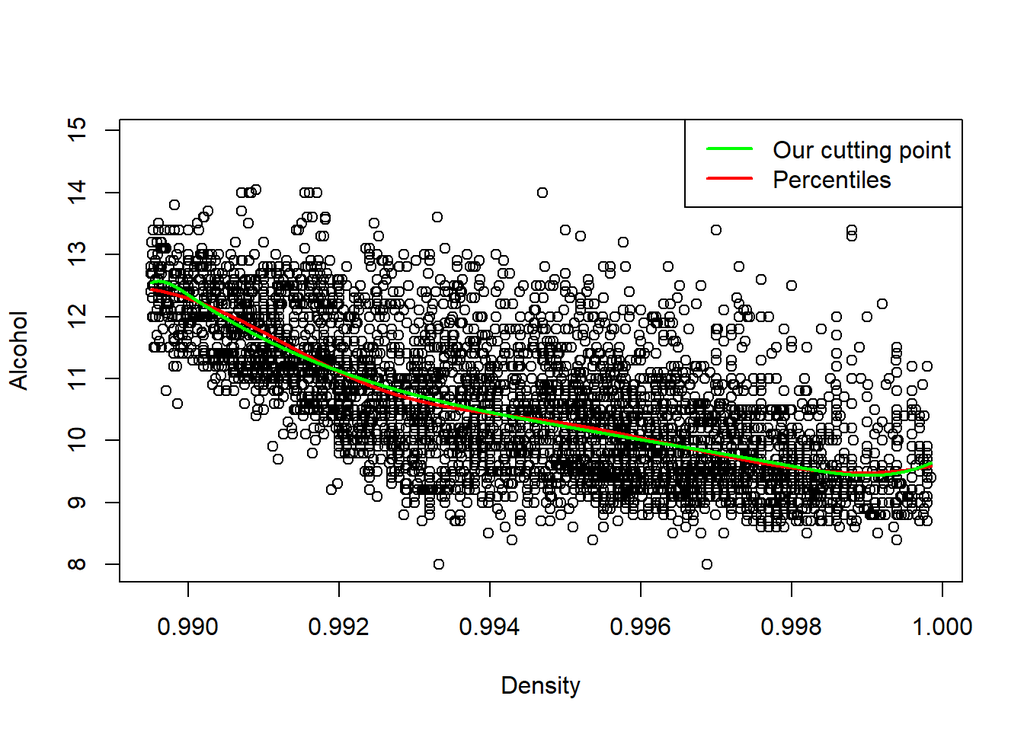

```r
#comparing
#Plotting the Regression Line to the scatterplot
plot(density,alcohol,col="black",xlab="Density",ylab="Alcohol")
points(density.grid,fit0_pre,,col="red",lwd=2,type="l")
points(density.grid,fit_pre,col="green",lwd=2,type="l")
legend("topright",c("Our cutting point","Percentiles"),col=c("green","red"),lwd=2)
```

**Conclusion**

Comparing the two regression lines, we can see that they are both similar in shape, but the shape differ slightly at density=0.990 (which is the knot for the green line).